# Lotka-Volterra-model with resource dependency

## Basic model

### Equations

| $\frac{dX}{dt} = a \cdot X - b \cdot X \cdot Y$ | prey (producer) |
| --- | --- |
| $\frac{dY}{dt} = g \cdot b \cdot X \cdot Y - e \cdot Y$ | predator (consumer) |

**ToDo** use consistent naming

## Model with logistic term

### Implementation

```r
require(deSolve)
```

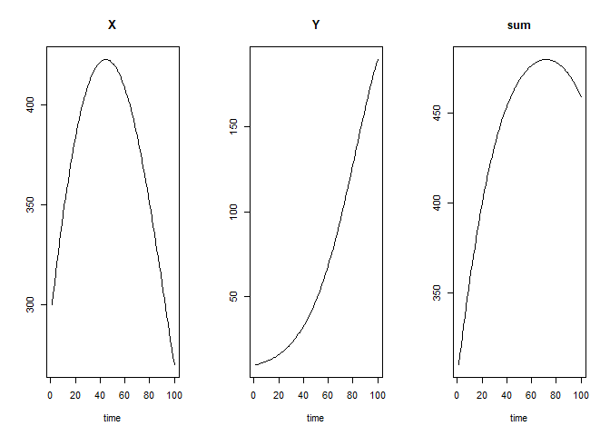

```r
state.ini <- c(X=300, Y=10)            # state variable initial conditions
parms     <- c(a=0.05, K=500, b=0.0002, g=0.8, e=0.03)  # parameter values

LVmodel <- function(t, state, parameters) {
  with (as.list(c(state, parameters)), {
    Growth.X     <- a*X*(1-X/K)
    Grazing.Y    <- b*X*Y
    Mortality.Y  <- e*Y
    dX.dt <- Growth.X  - Grazing.Y
    dY.dt <- g*Grazing.Y - Mortality.Y
    return (list(c(dX.dt, dY.dt),  # vector of derivatives
                 sum = X+Y))       # output variable
  })
}
times <- 1:100
out   <- ode(y = state.ini, func = LVmodel, times = times, parms = parms)
plot(out, mfrow = c(1,3))
```

## Resouce dependent model

| $\frac{dS}{dt} = s_{in}(t) - b \cdot S \cdot P + g \cdot K$ | resource (substrate) |
| --- | --- |
| $\frac{dP}{dt} = c \cdot S \cdot P - d \cdot K \cdot P$ | prey (producer) |
| $\frac{dK}{dt} = e \cdot P \cdot K - f \cdot K$ | predator (consumer) |
| with: |  |
| $s_{in}(t) = s_{in} + f_{pulse}(t, s_{start}, s_{duration}, s_{pulse})$ | substrate import |

Here $c$ controls the growth rate of the producer, $d$ and $e$ describe interaction between producer and consumer and $f$ mortality of the consumer.

The additional equation $dS/dt$ describes an essential resource $S$, substrate), necessary for growth of the producer. The parameter $b$ defines resource utilization by the producer and $g$ allows to simulate substrate recycling.

An additional time-dependent **forcing function** $s_{in}(t)$, allows to simulate a substrate import pulse with `s_pulse` = height, `s_start` = time and `s_duration` = duration of additional substrate import.

## Exercises

Aim is to understand the most important properties of the model. It is of course possible to analyse the model mathematically with pen and paper or by simulation with trial and error. Our approach is to start with the latter and then go back to theory.

**Important:** It is always a good idea to make some minutes during experimentation. Write down, how parameters change system behavior with respect to amplitude, frequency and shape of the time series. In addition to time series plots, plot also the states.

## References

Hindmarsh, Alan C. (1983) ODEPACK, A Systematized Collection of ODE Solvers. In: Stepleman, R.W. et al. (ed.) Scientific Computing, p.55-64. North-Holland, Amsterdam.

Soetaert, Karline; Petzoldt, Thomas and R. Woodrow Setzer (2010) Solving Differential Equations in R: Package deSolve. Journal of Statistical Software, 33(9), 1-25. http://www.jstatsoft.org/v33/i09/

Volterra, V. (1926) Fluctuations in the Abundance of a Species considered Mathematically. Nature 118, 558-560.

[ThPe](http://tu-dresden.de/Members/thomas.petzoldt)